# Practical work 1: introduction and image enhancement

- Quick start for Python (10 minutes!) : https://www.stavros.io/tutorials/python/
- Quick start for Numpy : https://numpy.org/devdocs/user/quickstart.html#
- For Matlab users: Numpy is very similar but with some important difference, see http://mathesaurus.sourceforge.net/matlab-numpy.html.
- Keep in mind that in Python, exception of variable of scalar type, all is reference and affectation is not a copy.

## Short introduction to image processing with Python

Help: use the function `help()` to get information on a Python objet.

Images are stored as arrays that is the default type of the `numpy` module. Defaut type of array elements is `float64` according to the IEEE754 norm. Special float values are defined: infinity (`inf`) and undefined (`nan`, *not a number*), and some numerical constants, such as $\pi$.

```python
# import numpy
import numpy as np

# predefined constants
print(np.inf,np.nan,np.pi)

# some values
print( 1., 1e10, -1.2e-3)
```

```
inf nan 3.141592653589793
1.0 10000000000.0 -0.0012
```

### Creating an array: several ways.

1. From a list of values (formally any Python iterable object). Elements of an array have the same **type**, determined by Numpy:

```python
V = np.array([1,2,3])
M = np.array([[1,2,3],[4,5,6.]])
print ("V is of type",V.dtype)
print ("M is of type",I.dtype)
```

[output not shown]

1. Without values: Numpy has constructors such as `empty()`, `zeros()`, `ones()`... Shape should be given (see below). Important: `empty()` does not initialize array elements.

```python
I = np.zeros((3,4))
print(I)
J = np.empty((4,3))
print(J)
```

```
[[0. 0. 0. 0.]
 [0. 0. 0. 0.]
 [0. 0. 0. 0.]]
[[0. 0. 0.]
 [0. 0. 0.]
 [0. 0. 0.]
 [0. 0. 0.]]
```

1. From a sequence, prefer `arange()` from numpy to `range()` from python.

```python
print(np.arange(10))
print(np.arange(0,10,2))
print(np.arange(9,-1,-.5))
```

```
[0 1 2 3 4 5 6 7 8 9]
[0 2 4 6 8]
[ 9.   8.5  8.   7.5  7.   6.5  6.   5.5  5.   4.5  4.   3.5  3.   2.5
  2.   1.5  1.   0.5  0.  -0.5]
```

### Shape of an array

Shape decribes the number of elements for each dimension. A vector is of dimension 1, a matrix is of dimension 2. Superior dimensions are possible. Shape is not size that is the number of elements of an array. Type of shape is always a tuple of integers. With previous example:

```python
print(I.shape, I.size)
print(J.shape, J.size)
print(V.shape, V.size)
```

```
(3, 4) 12
(4, 3) 12
(3,) 3
```

An important function/method is `reshape()` to change the shape of an array. Typical usage of `reshape()` is to transform a vector into a matrix or reciprocally.

```python
K = np.arange(12).reshape((3,4))
print(K)
print(np.reshape(K,(12)))
print(K.reshape((2,2,3)))
```

```
[[ 0  1  2  3]
 [ 4  5  6  7]
 [ 8  9 10 11]]
[ 0  1  2  3  4  5  6  7  8  9 10 11]
[[[ 0  1  2]
  [ 3  4  5]]

 [[ 6  7  8]
  [ 9 10 11]]]
```

### Elements of an array

Access element by indices: two syntaxe are possible, the first given in the example is prefered. Negative index is possible with the same meanning of Python list.

```python
I = np.arange(12).reshape((3,4))
print(I[1,2])
print(I[0][0])
print(I[-1,0])
```

```
6
0
8
```

Access by group of indices using the operator `:` allows to extract subarray. General syntaxe is `start:end:step` and it is very powerfull:

```python
print('extract the first line')
print(I[0,:])
print(I[0,0:])
print(I[0,::])
print(I[0,::1])

print('extract center of the array')
print(I[1:3,1:3])

print('extract elements with even indices')
print(I[::2,::2])

print('print the horizontal mirror of an array')
print(I[:,::-1])
```

```
extract the first line
[0 1 2 3]
[0 1 2 3]
[0 1 2 3]
[0 1 2 3]
extract center of the array
[[ 5  6]
 [ 9 10]]
extract elements with even indices
[[ 0  2]
 [ 8 10]]
print the horizontal mirror of an array
[[ 3  2  1  0]
 [ 7  6  5  4]
 [11 10  9  8]]
```

### Array arithmetic

Operators and functions can be applied to arrays. Mostly, operations are element-wise (i.e. applied element by element). The consequence is arrays should have the same shape. One operand can also be scalar in most of time.

```python
A = np.arange(12).reshape((3,4))
B = 2 * A + 1
C = A + B
D = np.cos(2*np.pi*A/12)

print (D)
print (D**2)
print (D>0)
```

```
[[ 1.00000000e+00  8.66025404e-01  5.00000000e-01  6.12323400e-17]
 [-5.00000000e-01 -8.66025404e-01 -1.00000000e+00 -8.66025404e-01]
 [-5.00000000e-01 -1.83697020e-16  5.00000000e-01  8.66025404e-01]]
[[1.00000000e+00 7.50000000e-01 2.50000000e-01 3.74939946e-33]
 [2.50000000e-01 7.50000000e-01 1.00000000e+00 7.50000000e-01]
 [2.50000000e-01 3.37445951e-32 2.50000000e-01 7.50000000e-01]]
[[ True  True  True  True]
 [False False False False]
 [False False  True  True]]
```

Array may be viewed as matrix, we can make some linear algebraic manipulation. For example, `np.matmul()` is the matrix multiplication. It can be used to build matrix from vector. An example, using the transpose operator `T`.

```python
L = np.arange(1,6).reshape((1,5))
# transpose of L. Warning: C remains a reference to L
C = L.T
# This could be better if your want to touch L
C = L.T.copy()

print("A 5*5 matrix:")
print(np.matmul(C,L))

print("A dot product, but result is a matrix:")
print(np.matmul(L,C))
print(np.matmul(L,C)[0,0])

print("dot() is prefered with vectors:")
V = np.arange(1,6)
print(V.dot(V))
print(np.dot(V,V))
```

```
A 5*5 matrix:
[[ 1  2  3  4  5]
 [ 2  4  6  8 10]
 [ 3  6  9 12 15]
 [ 4  8 12 16 20]
 [ 5 10 15 20 25]]
A dot product, but result is a matrix:
[[55]]
55
dot() is prefered with vectors:
55
55
```

### Images

We make use of PIL module (https://pillow.readthedocs.io/en/stable/reference/Image.html) to load and write an image and easily converted to Numpy array. Be careful: array type depends on image.

```python
from PIL import Image

# reading an image and convert to array
myimage = np.array(Image.open('img/moon.png'))

# write an image (alternative format) from an array
Image.fromarray(myimage).save('image.jpg')
```

Array can be displayed as an image using Matplotlib module. Here a short example:

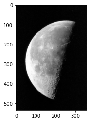

```python
import matplotlib.pyplot as plt

# minimal example:
plt.imshow(myimage)
plt.show()

# with more controls:
w,h=400,400
plt.figure(figsize=(w/80,h/80))  # optional, to control the size of figure (unit: pixel)
plt.gray() # optional call to display image using a gray colormap
plt.title('This is an image') # optional: add a title
plt.axis('off') # optional: remove axes
plt.imshow(myimage)
plt.show()
```

See also:

- https://matplotlib.org/3.1.1/tutorials/introductory/images.html
- https://matplotlib.org/gallery/images_contours_and_fields/image_demo.html#sphx-glr-gallery-images-contours-and-fields-image-demo-py).

## Exercice 1

In this exercice, we work with image `img/moon.png`. If possible give two solutions : one with loops (for, while, ...) and one without loops.

1. Write and test a function `openImage()` getting an image filename as argument and returning the array of pixel values.

```python
from PIL import Image
import numpy as np

def openImage(fname):
    """ str -> Array
    (notation above means the function gets a string argument and returns an Array object)
    """
    return np.array(Image.open(fname))
```

```python
# reading an image and convert to array
monimage = openImage('img/moon.png')

# write an image (alternative format) from an array
Image.fromarray(monimage).save('image.jpg')
```

```python
# with more controls:
w,h=400,400
plt.figure(figsize=(w/80,h/80))  # optional, to control the size of figure (unit: pixel)
plt.gray() # optional call to display image using a gray colormap
plt.title('This is an image') # optional: add a title
plt.axis('off') # optional: remove axes
plt.imshow(monimage)
plt.show()
```

[output not shown]

1. Write and test a function `countPixels()` getting an array and an integer `k` as arguments and returning the number of pixels having the value `k`.

##### Using loop .</h3>

```python
def countPixels(I,k):
    """ Array*int -> int"""
    """
        la fonction parcour tout les pixels
        de l'image et vérifie si sa valeur est
        egale a k
    """


    nbPixels = 0
    for i in I:
        for j in i :
            if j == k :
                nbPixels +=1
    return nbPixels
```

```python
print(countPixels(openImage('img/moon.png'),0))
```

```
1459
```

##### Using Numpy .</h3>

```python
def countPixels(I,k):
    """ Array*int -> int"""

    return ((I==k).sum())
```

```python
print(countPixels(openImage('img/moon.png'),0))
```

```
1459
```

1. Write and test a function `replacePixels()` getting an array and two intergers and replacing pixels having `k1`value to `k2` value and returning the new array. Be aware to not modify `I`.

##### Using Numpy .</h3>

```python
def replacePixels(I,k1,k2):
    """ Array*int*int -> Array """

    return np.where(I==k1, k2, I)
```

```python
a=np.array([[1,2,3,4],[2,4,5,3]])
print(replacePixels(a,2,3))
```

```
[[1 3 3 4]
 [3 4 5 3]]
```

##### Using loop .</h3>

```python
def replacePixels(I,k1,k2):
    """ Array*int*int -> Array """

    for i in range(len(I)):
        for j in range(len(I[0])):
            if I[i][j] == k1 :
                I[i][j]=k2
    return I
```

```python
a=np.array([[1,2,3,4],[2,4,5,3]])
print(replacePixels(a,2,3))
```

```
[[1 3 3 4]
 [3 4 5 3]]
```

1. Write and test a function `normalizeImage()` getting an array and two integers `k1` and `k2` and returning an array with elements normalized to the interval $[k_1,k_2]$.

##### Using loop .</h3>

```python
def normalizeImage(I,k1,k2):
    """ Array*int*int -> Array """
    kMax = np.amax(I)
    kMin = np.min(I)
    im = np.copy(I)

    for i in range(len(I)):
        for j in range(len(I[0])):
            im[i][j] = (k2-k1)*((I[i][j]-kMin)/(kMax-kMin)) + k1

    return im
```

```python
a=np.array([[1,2,3,4],[2,4,5,3]])
print(normalizeImage(a,1,3))
```

```
[[1 1 2 2]
 [1 2 3 2]]
```

##### Using Numpy .</h3>

```python
def normalizeImage(I,k1,k2):
    """ Array*int*int -> Array """

    kmin=np.min(I)
    kmax=np.max(I)
    return (np.where(I>=0,k1+(I-kmin)*((k2-k1)/(kmax-kmin)),I)).astype(int)
```

```python
a=np.array([[1,2,3,4],[2,4,5,3]])
print(normalizeImage(a,1,3))
```

```
[[1 1 2 2]
 [1 2 3 2]]
```

1. Write and test a function `inverteImage()` getting an array and returning and arry having inverted pixel values (i.e. the transform $k \mapsto 255-k$

##### Using loop .</h3>

```python
def inverteImage(I):
    """ Array -> Array """

    im = np.copy(I)
    for i in range(len(I)):
        for j in range(len(I[0])):
            im[i][j] = 255 - im[i][j]
    return im
```

```python
a=np.array([[1,2,3,4],[2,4,5,3]])
print(inverteImage(a))
```

```
[[254 253 252 251]
 [253 251 250 252]]
```

##### Using Numpy .</h3>

```python
def inverteImage(I):
    """ Array -> Array """
    return np.where(I>=0,255-I,I)
```

```python
a=np.array([[1,2,3,4],[2,4,5,3]])
print(inverteImage(a))
```

```
[[254 253 252 251]
 [253 251 250 252]]
```

1. Write and test a function `computeHistogram()` getting an array and returning its histogram. Type of histogram can be an array or a list. It is forbidden to use an histogram method from a Python module. Is it possible to compute the histogram without explicitely visiting array pixels?

##### Using loop .</h3>

```python
def computeHistogram(I):
    """ Array -> list[int] """
    h1=np.arange(256)
    h2=np.zeros(256)
    for i in h1:
        h2[i]=np.sum(I==i)
    return (np.array([h1,h2])).astype(int)

#TEST
a=np.array([[1,2,3,4],[2,4,5,3]])
print(computeHistogram(a))
# use comments to answer to a verbal question
```

```
[[  0   1   2   3   4   5   6   7   8   9  10  11  12  13  14  15  16  17
   18  19  20  21  22  23  24  25  26  27  28  29  30  31  32  33  34  35
   36  37  38  39  40  41  42  43  44  45  46  47  48  49  50  51  52  53
   54  55  56  57  58  59  60  61  62  63  64  65  66  67  68  69  70  71
   72  73  74  75  76  77  78  79  80  81  82  83  84  85  86  87  88  89
   90  91  92  93  94  95  96  97  98  99 100 101 102 103 104 105 106 107
  108 109 110 111 112 113 114 115 116 117 118 119 120 121 122 123 124 125
  126 127 128 129 130 131 132 133 134 135 136 137 138 139 140 141 142 143
  144 145 146 147 148 149 150 151 152 153 154 155 156 157 158 159 160 161
  162 163 164 165 166 167 168 169 170 171 172 173 174 175 176 177 178 179
  180 181 182 183 184 185 186 187 188 189 190 191 192 193 194 195 196 197
  198 199 200 201 202 203 204 205 206 207 208 209 210 211 212 213 214 215
  216 217 218 219 220 221 222 223 224 225 226 227 228 229 230 231 232 233
  234 235 236 237 238 239 240 241 242 243 244 245 246 247 248 249 250 251
  252 253 254 255]
 [  0   1   2   2   2   1   0   0   0   0   0   0   0   0   0   0   0   0
    0   0   0   0   0   0   0   0   0   0   0   0   0   0   0   0   0   0
    0   0   0   0   0   0   0   0   0   0   0   0   0   0   0   0   0   0
    0   0   0   0   0   0   0   0   0   0   0   0   0   0   0   0   0   0
    0   0   0   0   0   0   0   0   0   0   0   0   0   0   0   0   0   0
    0   0   0   0   0   0   0   0   0   0   0   0   0   0   0   0   0   0
    0   0   0   0   0   0   0   0   0   0   0   0   0   0   0   0   0   0
    0   0   0   0   0   0   0   0   0   0   0   0   0   0   0   0   0   0
    0   0   0   0   0   0   0   0   0   0   0   0   0   0   0   0   0   0
    0   0   0   0   0   0   0   0   0   0   0   0   0   0   0   0   0   0
    0   0   0   0   0   0   0   0   0   0   0   0   0   0   0   0   0   0
    0   0   0   0   0   0   0   0   0   0   0   0   0   0   0   0   0   0
    0   0   0   0   0   0   0   0   0   0   0   0   0   0   0   0   0   0
    0   0   0   0   0   0   0   0   0   0   0   0   0   0   0   0   0   0
    0   0   0   0]]
```

```python
#TEST
a=np.array([[1,2,120,255],[2,4,5,3]])
print(computeHistogram(a))
```

```
[[  0   1   2   3   4   5   6   7   8   9  10  11  12  13  14  15  16  17
   18  19  20  21  22  23  24  25  26  27  28  29  30  31  32  33  34  35
   36  37  38  39  40  41  42  43  44  45  46  47  48  49  50  51  52  53
   54  55  56  57  58  59  60  61  62  63  64  65  66  67  68  69  70  71
   72  73  74  75  76  77  78  79  80  81  82  83  84  85  86  87  88  89
   90  91  92  93  94  95  96  97  98  99 100 101 102 103 104 105 106 107
  108 109 110 111 112 113 114 115 116 117 118 119 120 121 122 123 124 125
  126 127 128 129 130 131 132 133 134 135 136 137 138 139 140 141 142 143
  144 145 146 147 148 149 150 151 152 153 154 155 156 157 158 159 160 161
  162 163 164 165 166 167 168 169 170 171 172 173 174 175 176 177 178 179
  180 181 182 183 184 185 186 187 188 189 190 191 192 193 194 195 196 197
  198 199 200 201 202 203 204 205 206 207 208 209 210 211 212 213 214 215
  216 217 218 219 220 221 222 223 224 225 226 227 228 229 230 231 232 233
  234 235 236 237 238 239 240 241 242 243 244 245 246 247 248 249 250 251
  252 253 254 255]
 [  0   1   2   1   1   1   0   0   0   0   0   0   0   0   0   0   0   0
    0   0   0   0   0   0   0   0   0   0   0   0   0   0   0   0   0   0
    0   0   0   0   0   0   0   0   0   0   0   0   0   0   0   0   0   0
    0   0   0   0   0   0   0   0   0   0   0   0   0   0   0   0   0   0
    0   0   0   0   0   0   0   0   0   0   0   0   0   0   0   0   0   0
    0   0   0   0   0   0   0   0   0   0   0   0   0   0   0   0   0   0
    0   0   0   0   0   0   0   0   0   0   0   0   1   0   0   0   0   0
    0   0   0   0   0   0   0   0   0   0   0   0   0   0   0   0   0   0
    0   0   0   0   0   0   0   0   0   0   0   0   0   0   0   0   0   0
    0   0   0   0   0   0   0   0   0   0   0   0   0   0   0   0   0   0
    0   0   0   0   0   0   0   0   0   0   0   0   0   0   0   0   0   0
    0   0   0   0   0   0   0   0   0   0   0   0   0   0   0   0   0   0
    0   0   0   0   0   0   0   0   0   0   0   0   0   0   0   0   0   0
    0   0   0   0   0   0   0   0   0   0   0   0   0   0   0   0   0   0
    0   0   0   1]]
```

1. Write and test a function `thresholdImage()` getting an array `I` and an integer `s` and returning an array having elements set to 0 if corresponding element of `I` is lower than `s` or 255 otherwise.

##### Using Numpy .</h3>

```python
def thresholdImage(I,s):
    """ Array*int -> Array """


    return np.where(I>=s,255,0)
```

```python
a=np.array([[1,2,3,4],[2,4,5,3]])
print(thresholdImage(a,3))
```

```
[[  0   0 255 255]
 [  0 255 255 255]]
```

##### Using loop .</h3>

```python
def thresholdImage(I,s):
    """ Array*int -> Array """

    im = np.copy(I)
    for i in range(len(I)):
        for j in range(len(I[0])):
            if im[i][j] < s :
                im[i][j] = 0
            else:
                im[i][j] =255

    return im
```

```python
a=np.array([[1,2,3,4],[2,4,5,3]])
print(thresholdImage(a,3))
```

```
[[  0   0 255 255]
 [  0 255 255 255]]
```

1. Using previous functions, give a series of instructions to read then to display an image, plot the histogram (one can use `plot()` or `bar()` from `matplotlib.pyplot` module), inverse the image and display it, plot its histogram.

```python
# with more controls:
w,h=400,400
plt.figure(figsize=(w/80,h/80))  # optional, to control the size of figure (unit: pixel)
plt.gray() # optional call to display image using a gray colormap
plt.title('This is an image') # optional: add a title
plt.axis('off') # optional: remove axes
plt.imshow(monimage)
plt.show()
```

[output not shown]

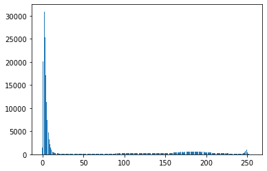

```python
import matplotlib.pyplot as plt

## your code start below
hist = computeHistogram(openImage('img/moon.png'))
plt.bar(hist[0],hist[1])
plt.show()
```

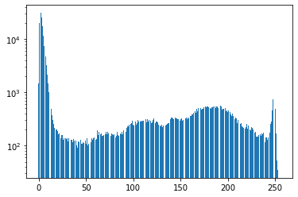

```python
plt.figure()
plt.bar(hist[0],hist[1],log='true')
plt.show()
```

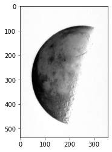

```python
im2 = inverteImage(openImage('img/moon.png'))
plt.imshow(im2)
plt.show()
hist2=computeHistogram(im2)
```

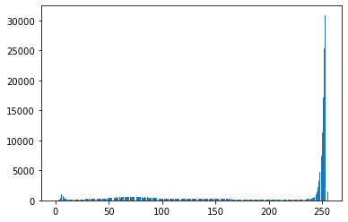

```python
plt.figure()
plt.bar(hist2[0],hist2[1])
plt.show()
```

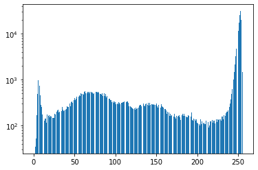

```python
plt.figure()
plt.bar(hist2[0],hist2[1],log='true')
plt.show()
```

1. Give a series of instructions to read and display an image, plot the histogram, normalize the image to the interval $[10,50]$, compute the new histogram, display the image and the histogram. Remark: `imshow()` normalizes image. To avoid this and see the effect of the normalization, use `imshow()` with parameters `vmin=0,vmax=255`. Comment the results.

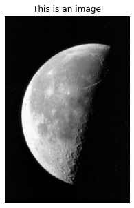

```python
# with more controls:
w,h=400,400
plt.figure(figsize=(w/80,h/80))  # optional, to control the size of figure (unit: pixel)
plt.gray() # optional call to display image using a gray colormap
plt.title('This is an image') # optional: add a title
plt.axis('off') # optional: remove axes
plt.imshow(monimage,vmin=0,vmax=255)
plt.show()
```

```python
im = normalizeImage(monimage,10,50)
```

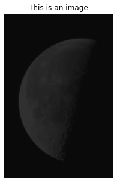

```python
w,h=400,400
plt.figure(figsize=(w/80,h/80))  # optional, to control the size of figure (unit: pixel)
plt.gray() # optional call to display image using a gray colormap
plt.title('This is an image') # optional: add a title
plt.axis('off') # optional: remove axes
plt.imshow(im,vmin=0,vmax=255)
plt.show()
```

1. Same question than 9. remplacing the normalization by a thresholding with parameter $s=127$.

```python
im2 = thresholdImage(monimage,127)
```

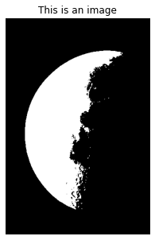

```python
w,h=400,400
plt.figure(figsize=(w/80,h/80))  # optional, to control the size of figure (unit: pixel)
plt.gray() # optional call to display image using a gray colormap
plt.title('This is an image') # optional: add a title
plt.axis('off') # optional: remove axes
plt.imshow(im2,vmin=0,vmax=255)
plt.show()
```

## Exercice 2 - generate images

1. Create the array `I` 4 by 4 corresponding to the following image:

[figure not shown]

   Black pixels have value 0, white pixels value 255, and grey pixels value 127. Display the image using `imshow()` and plot the histogram.

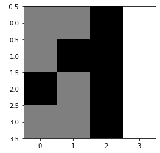

```python
I=np.array([[127,127,0,255],[127,0,0,255],[0,127,0,255],[127,127,0,255]])
plt.imshow(I)
```

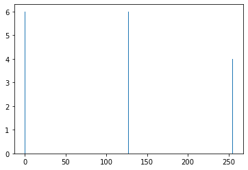

```python
plt.figure()
his=computeHistogram(I)
plt.bar(his[0],his[1])
plt.show()
```

1. We want to generate a matrix having random values. Functions `rand()` and `randn()` from `numpy.matlib` module generate array of given shape with random values following respectively a uniform distribution on $[0,1[$ and a normal distribution. Create an array of shape 512 by 512 having **integer** elements following an uniform distribution in the set $\{0,1,\cdots,255\}$ . We also want to create an array following a gaussian distribution with a mean of 128 and a standard deviation of 16 and with **integer** values. Display the images and their histogramms. Discuss the results.

```python
import numpy.matlib as m

#img1 512*512 array of integer between 0 and 255 following a uniform distibution
pic1=np.array((m.rand(512,512)*256).astype(int))
#img1 512*512 array of integer between 0 and 255 following a normal distribution
pic2=np.array((16*m.randn(512,512)+128).astype(int))
```

[figure not shown]

```python
w,h=400,400
plt.figure(figsize=(w/80,h/80))  # optional, to control the size of figure (unit: pixel)
plt.gray() # optional call to display image using a gray colormap
plt.title('The image corresponding to the uniform dist') # optional: add a title
plt.axis('off') # optional: remove axes
plt.imshow(pic1)
plt.show()
```

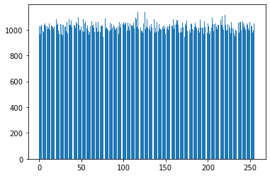

```python
plt.figure()
his=computeHistogram(pic1)
plt.bar(his[0],his[1])
plt.show()
```

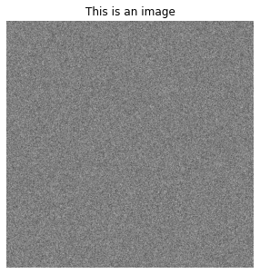

```python
w,h=400,400
plt.figure(figsize=(w/80,h/80))  # optional, to control the size of figure (unit: pixel)
plt.gray() # optional call to display image using a gray colormap
plt.title('This is an image') # optional: add a title
plt.axis('off') # optional: remove axes
plt.imshow(pic2)
plt.show()
```

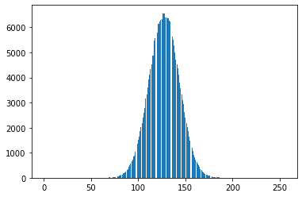

```python
plt.figure()
his=computeHistogram(pic2)
plt.bar(his[0],his[1])
plt.show()
```

## Exercice 3: image manipulation

In this exercice, we work with image `img/pout.png`.

1. Read and display this image

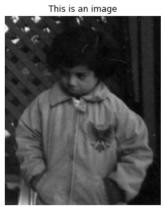

```python
w,h=400,400
plt.figure(figsize=(w/80,h/80))  # optional, to control the size of figure (unit: pixel)
plt.gray() # optional call to display image using a gray colormap
plt.title('This is an image') # optional: add a title
plt.axis('off') # optional: remove axes
plt.imshow(openImage('img/pout.png'))
plt.show()
```

1. Examine the histogram. Determine the extrema of the image. What can you say about the quality of this image?

```python
pout = computeHistogram(openImage('img/pout.png'))
```

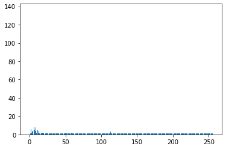

```
' \n    on remarque que le contrasete est faible \n'
```

```python
plt.figure()
his=computeHistogram(pout)
plt.bar(his[0],his[1])
plt.show()


"""
    on remarque que le contrasete est faible
"""
```

1. Using functions from Exercice 1, write the function `histogramEqualization()` getting one image, its histogram, applying an histogram equalization and returning the new image. Test this function on `pout.png` and discuss the result.

```python
def histogramCumule(h):
    """ list[int] -> list[int]  """

    hist = np.copy(h)
    for i in range(len(h[1])-1):
        hist[1][i+1] = hist[1][i]+hist[1][i+1]
    return hist
```

```python
poutCumule = histogramCumule(pout)
```

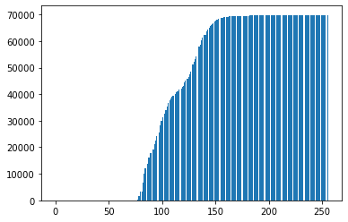

```python
plt.figure()
his=histogramCumule(pout)
plt.bar(his[0],his[1])
plt.show()
```

```python
def histogramEqualization(I,h):

    """ Array * (list[int] -> Array """

    hsitC = np.array(histogramCumule(h))
    histPic = normalizeImage(hsitC[1],0,255)

    im = np.copy(I)
    for i in range(len(I)):
        for j in range(len(I[0])):
            im[i][j] = histPic[im[i][j]]
    return im
```

```python
picture = computeHistogram(histogramEqualization(openImage('img/pout.png'),pout))
```

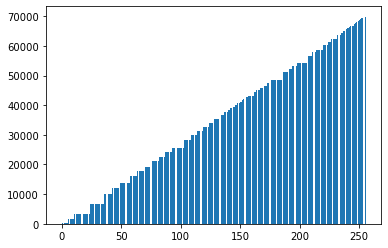

```python
plt.figure()
his=histogramCumule(picture)
plt.bar(his[0],his[1])
plt.show()
```

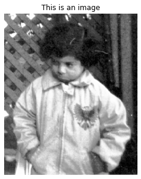

```python
w,h=400,400
plt.figure(figsize=(w/80,h/80))  # optional, to control the size of figure (unit: pixel)
plt.gray() # optional call to display image using a gray colormap
plt.title('This is an image') # optional: add a title
plt.axis('off') # optional: remove axes
plt.imshow(histogramEqualization(openImage('img/pout.png'),pout))
plt.show()
```

```python
"""
    on voit que grace a la fonction histogramEqualization
    l'image a plus de détailles et cela revient au fait qu'on plus de
    valeurs des pixels et qu'ils sont mieux distribué

"""
```